# Master Notebook for Capstone Project: Women in Data Science predicting ADHD and Sex

Group 3

Shria Narapaneni, DePaul University, snarapan@depaul.edu

Johnathen Kent, DePaul University, jkent@depaul.edu

Fernanda Cabral, DePaul University, fcabral3@depaul.edu

Sai Kiran Bommena, DePaul University, sbommena@depaul.edu

### Initial EDA: Fernanda Cabral

```python
import pandas as pd
#import data
fmri_data = pd.read_csv("C:\\Users\\fscab_53shzay\\Documents\DePaulUniversity\\5th Year\\Capstone\\widsdatathon2025\\TRAIN_NEW\\TRAIN_FUNCTIONAL_CONNECTOME_MATRICES_new_36P_Pearson.csv")
cat_data = pd.read_excel("C:\\Users\\fscab_53shzay\Documents\DePaulUniversity\\5th Year\\Capstone\\widsdatathon2025\\TRAIN_NEW\\TRAIN_CATEGORICAL_METADATA_new.xlsx")
numerical_data = pd.read_excel("C:\\Users\\fscab_53shzay\\Documents\DePaulUniversity\\5th Year\\Capstone\\widsdatathon2025\\TRAIN_NEW\\TRAIN_QUANTITATIVE_METADATA_new.xlsx")
labels = pd.read_excel("C:\\Users\\fscab_53shzay\\Documents\DePaulUniversity\\5th Year\\Capstone\\widsdatathon2025\\TRAIN_NEW\\TRAINING_SOLUTIONS.xlsx")
```

```python
def load_and_merge_wids_data(functional_path, quantitative_path, categorical_path, targets_path=None):
    import pandas as pd

    # Load files
    functional_df = pd.read_csv(functional_path)
    quantitative_df = pd.read_excel(quantitative_path)
    categorical_df = pd.read_excel(categorical_path)

    # Merge metadata
    metadata = pd.merge(quantitative_df, categorical_df, on="participant_id", how="inner")
    merged_df = pd.merge(functional_df, metadata, on="participant_id", how="inner")

    # Merge targets if available
    if targets_path:
        targets_df = pd.read_excel(targets_path)
        merged_df = pd.merge(merged_df, targets_df, on="participant_id", how="inner")

    return merged_df
```

```python
#loading and merging training data
train_df = load_and_merge_wids_data(
    "C:\\Users\\fscab_53shzay\\Documents\\DePaulUniversity\\5th Year\\Capstone\\widsdatathon2025\\TRAIN_NEW\\TRAIN_FUNCTIONAL_CONNECTOME_MATRICES_new_36P_Pearson.csv",
    "C:\\Users\\fscab_53shzay\\Documents\\DePaulUniversity\\5th Year\\Capstone\\widsdatathon2025\\TRAIN_NEW\\TRAIN_QUANTITATIVE_METADATA_new.xlsx",
    "C:\\Users\\fscab_53shzay\\Documents\\DePaulUniversity\\5th Year\\Capstone\\widsdatathon2025\\TRAIN_NEW\\TRAIN_CATEGORICAL_METADATA_new.xlsx",
    "C:\\Users\\fscab_53shzay\\Documents\\DePaulUniversity\\5th Year\\Capstone\\widsdatathon2025\\TRAIN_NEW\\TRAINING_SOLUTIONS.xlsx"
)

#train_df.to_csv('final_merged_training_data.csv',index=False)
```

```python
import pandas as pd

# loading test files to be merged
test_categorical = pd.read_excel("C:\\Users\\fscab_53shzay\\Documents\\DePaulUniversity\\5th Year\\Capstone\\widsdatathon2025\\TEST\\TEST_CATEGORICAL.xlsx")
test_quantitative = pd.read_excel("C:\\Users\\fscab_53shzay\\Documents\\DePaulUniversity\\5th Year\\Capstone\\widsdatathon2025\\TEST\\TEST_QUANTITATIVE_METADATA.xlsx")
test_connectome = pd.read_csv("C:\\Users\\fscab_53shzay\\Documents\\DePaulUniversity\\5th Year\\Capstone\\widsdatathon2025\\TEST\\TEST_FUNCTIONAL_CONNECTOME_MATRICES.csv")
```

```python
#import merged dataset: training and testing
train_df = pd.read_csv('C:\\Users\\fscab_53shzay\\Documents\\DePaulUniversity\\5th Year\\Capstone\\final_merged_training_data.csv')
test_df = pd.read_csv('C:\\Users\\fscab_53shzay\\Documents\\DePaulUniversity\\5th Year\\Capstone\\final_merged_test_data.csv')
```

```python
# Loading the merged dataset for feature engineering
df = pd.read_csv("C:\\Users\\fscab_53shzay\\Documents\\DePaulUniversity\\5th Year\\Capstone\\final_combined_data_update3.csv")
```

```python
#check missing data
#print(fmri_data.isna().sum()) #none missing
#print(cat_data.isna().sum()) #some missing
#print(numerical_data.isna().sum()) #some missing
#print(labels.isna().sum()) #none missing
```

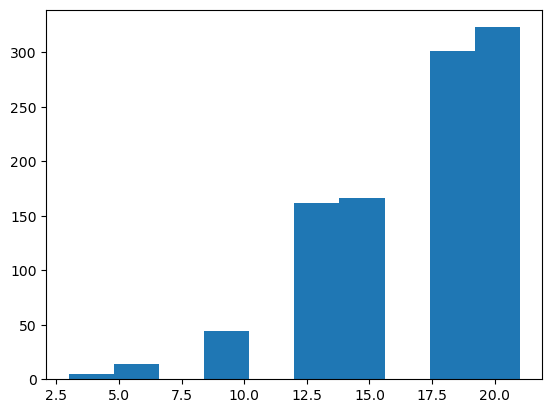

```python
import matplotlib.pyplot as plt

#plt.hist(cat_data['PreInt_Demos_Fam_Child_Ethnicity'])

#plt.hist(cat_data['PreInt_Demos_Fam_Child_Race'])

#plt.hist(cat_data['MRI_Track_Scan_Location'])

plt.hist(cat_data['Barratt_Barratt_P2_Edu'])
```

# Dictionary for

### 'PreInt_Demos_Fam_Child_Ethnicity'

0= Not Hispanic or Latino  
1= Hispanic or Latino  
2= Decline to specify  
3= Unknown"

### 'PreInt_Demos_Fam_Child_Race'

"0= White/Caucasian  
1= Black/African American  
2= Hispanic  
3= Asian  
4= Indian  
5= Native American Indian  
6= American Indian/Alaskan Native  
7= Native Hawaiian/Other Pacific Islander  
8= Two or more races  
9= Other race  
10= Unknown  
11=Choose not to specify"

### 'MRI_Track_Scan_Location'

"1=Staten Island  
2=RUBIC  
3=CBIC  
4=CUNY"

### 'Barratt_Barratt_P1_Edu'

"3=Less than 7th grade  
6=Junior high/Middle school (9th grade)  
9=Partial high school (10th or 11th grade)  
12=High school graduate  
15=Partial college (at least one year)  
18=College education  
21=Graduate degree"

### 'Barratt_Barratt_P2_Edu'

3=Less than 7th grade  
6=Junior high/Middle school (9th grade)  
9=Partial high school (10th or 11th grade)  
12=High school graduate  
15=Partial college (at least one year)  
18=College education  
21=Graduate degree"

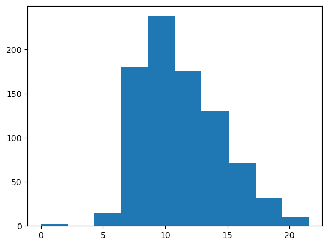

```python
import matplotlib.pyplot as plt
plt.hist(numerical_data['MRI_Track_Age_at_Scan'])
```

```python
## handling missing values
import statistics
#replace age with the mean

for column in numerical_data.columns:
    if numerical_data[column].isna().sum()>0:
        numerical_data[column] = numerical_data[column].fillna(numerical_data[column].mean())
numerical_data.isna().sum()
#replace categorical with the mode value? or remove entirely
for column in cat_data.columns:
    if cat_data[column].isna().sum()>0:
        m = statistics.mode(cat_data[column])
        cat_data[column] = cat_data[column].fillna(m)
cat_data.isna().sum()
```

```
participant_id                      0
Basic_Demos_Enroll_Year             0
Basic_Demos_Study_Site              0
PreInt_Demos_Fam_Child_Ethnicity    0
PreInt_Demos_Fam_Child_Race         0
MRI_Track_Scan_Location             0
Barratt_Barratt_P1_Edu              0
Barratt_Barratt_P1_Occ              0
Barratt_Barratt_P2_Edu              0
Barratt_Barratt_P2_Occ              0
dtype: int64
```

# EDA

### Johnathen Kent

```python
import pandas as pd
import numpy as np
import matplotlib.pyplot as plt
import seaborn as sns
import re

# Subset for EDA: remove connectome features
eda_df = train_df.loc[:, ~train_df.columns.str.match(r'^\d+throw_')]
connectome_df = train_df.loc[:, train_df.columns.str.match(r'^\d+throw_')]

# Summary stats
summary = pd.DataFrame({
    "Column Name": eda_df.columns,
    "Data Type": eda_df.dtypes,
    "Missing Values": eda_df.isnull().sum(),
    "Unique Values": eda_df.nunique()
})
totalMissingValues = eda_df.isnull().sum().sum()
print(summary)
print('Number of Missing Values:', totalMissingValues)
eda_df.describe()
```

```
                                                       Column Name Data Type  \
participant_id                                      participant_id    object
EHQ_EHQ_Total                                        EHQ_EHQ_Total   float64
ColorVision_CV_Score                          ColorVision_CV_Score   float64
APQ_P_APQ_P_CP                                      APQ_P_APQ_P_CP   float64
APQ_P_APQ_P_ID                                      APQ_P_APQ_P_ID   float64
APQ_P_APQ_P_INV                                    APQ_P_APQ_P_INV   float64
APQ_P_APQ_P_OPD                                    APQ_P_APQ_P_OPD   float64
APQ_P_APQ_P_PM                                      APQ_P_APQ_P_PM   float64
APQ_P_APQ_P_PP                                      APQ_P_APQ_P_PP   float64
SDQ_SDQ_Conduct_Problems                  SDQ_SDQ_Conduct_Problems   float64
SDQ_SDQ_Difficulties_Total              SDQ_SDQ_Difficulties_Total   float64
SDQ_SDQ_Emotional_Problems              SDQ_SDQ_Emotional_Problems   float64
SDQ_SDQ_Externalizing                        SDQ_SDQ_Externalizing   float64
SDQ_SDQ_Generating_Impact                SDQ_SDQ_Generating_Impact   float64
SDQ_SDQ_Hyperactivity                        SDQ_SDQ_Hyperactivity   float64
SDQ_SDQ_Internalizing                        SDQ_SDQ_Internalizing   float64
SDQ_SDQ_Peer_Problems                        SDQ_SDQ_Peer_Problems   float64
SDQ_SDQ_Prosocial                                SDQ_SDQ_Prosocial   float64
MRI_Track_Age_at_Scan                        MRI_Track_Age_at_Scan   float64
Basic_Demos_Enroll_Year                    Basic_Demos_Enroll_Year     int64
Basic_Demos_Study_Site                      Basic_Demos_Study_Site     int64
PreInt_Demos_Fam_Child_Ethnicity  PreInt_Demos_Fam_Child_Ethnicity   float64
PreInt_Demos_Fam_Child_Race            PreInt_Demos_Fam_Child_Race   float64
MRI_Track_Scan_Location                    MRI_Track_Scan_Location   float64
Barratt_Barratt_P1_Edu                      Barratt_Barratt_P1_Edu   float64
Barratt_Barratt_P1_Occ                      Barratt_Barratt_P1_Occ   float64
Barratt_Barratt_P2_Edu                      Barratt_Barratt_P2_Edu   float64
Barratt_Barratt_P2_Occ                      Barratt_Barratt_P2_Occ   float64
ADHD_Outcome                                          ADHD_Outcome     int64
Sex_F                                                        Sex_F     int64

                                  Missing Values  Unique Values
participant_id                                 0            910
EHQ_EHQ_Total                                 12            133
ColorVision_CV_Score                          19             14
APQ_P_APQ_P_CP                                 9             10
APQ_P_APQ_P_ID                                 9             20
APQ_P_APQ_P_INV                                9             26
APQ_P_APQ_P_OPD                                9             21
```

[output cut: 9 more lines]

```
SDQ_SDQ_Peer_Problems                          8             10
SDQ_SDQ_Prosocial                              8             11
MRI_Track_Age_at_Scan                        276            626
Basic_Demos_Enroll_Year                        0              6
Basic_Demos_Study_Site                         0              4
PreInt_Demos_Fam_Child_Ethnicity              30              4
PreInt_Demos_Fam_Child_Race                   39             10
MRI_Track_Scan_Location                        1              4
Barratt_Barratt_P1_Edu                         7              7
Barratt_Barratt_P1_Occ                        17             10
Barratt_Barratt_P2_Edu                       143              7
Barratt_Barratt_P2_Occ                       157             10
ADHD_Outcome                                   0              2
Sex_F                                          0              2
Number of Missing Values: 827
```

|  | EHQ_EHQ_Total | ColorVision_CV_Score | APQ_P_APQ_P_CP | APQ_P_APQ_P_ID | APQ_P_APQ_P_INV | APQ_P_APQ_P_OPD | APQ_P_APQ_P_PM | APQ_P_APQ_P_PP | SDQ_SDQ_Conduct_Problems | SDQ_SDQ_Difficulties_Total | ... | Basic_Demos_Study_Site | PreInt_Demos_Fam_Child_Ethnicity | PreInt_Demos_Fam_Child_Race | MRI_Track_Scan_Location | Barratt_Barratt_P1_Edu | Barratt_Barratt_P1_Occ | Barratt_Barratt_P2_Edu | Barratt_Barratt_P2_Occ | ADHD_Outcome | Sex_F |
| --- | --- | --- | --- | --- | --- | --- | --- | --- | --- | --- | --- | --- | --- | --- | --- | --- | --- | --- | --- | --- | --- |
| count | 898.000000 | 891.000000 | 901.000000 | 901.000000 | 901.000000 | 901.000000 | 901.000000 | 901.000000 | 902.000000 | 902.000000 | ... | 910.000000 | 880.000000 | 871.000000 | 909.000000 | 903.000000 | 893.000000 | 767.000000 | 753.000000 | 910.000000 | 910.000000 |
| mean | 59.723953 | 13.379349 | 3.790233 | 13.367370 | 39.824639 | 17.980022 | 16.399556 | 25.571587 | 2.073171 | 12.331486 | ... | 2.041758 | 0.422727 | 2.180253 | 2.319032 | 17.890365 | 25.475924 | 17.029987 | 30.677291 | 0.693407 | 0.337363 |
| std | 49.297847 | 2.211761 | 1.319661 | 3.631865 | 4.861218 | 3.365782 | 5.021969 | 3.029967 | 2.056141 | 6.571546 | ... | 1.138589 | 0.671833 | 3.243863 | 0.747596 | 3.528494 | 16.822162 | 3.925931 | 13.637332 | 0.461333 | 0.473070 |
| min | -100.000000 | 0.000000 | 2.000000 | 6.000000 | 23.000000 | 7.000000 | 5.000000 | 16.000000 | 0.000000 | 0.000000 | ... | 1.000000 | 0.000000 | 0.000000 | 1.000000 | 3.000000 | 0.000000 | 3.000000 | 0.000000 | 0.000000 | 0.000000 |
| 25% | 46.670000 | 14.000000 | 3.000000 | 11.000000 | 37.000000 | 16.000000 | 13.000000 | 23.000000 | 0.000000 | 7.000000 | ... | 1.000000 | 0.000000 | 0.000000 | 2.000000 | 15.000000 | 5.000000 | 15.000000 | 20.000000 | 0.000000 | 0.000000 |
| 50% | 76.670000 | 14.000000 | 3.000000 | 13.000000 | 40.000000 | 18.000000 | 16.000000 | 26.000000 | 2.000000 | 12.000000 | ... | 1.000000 | 0.000000 | 0.000000 | 2.000000 | 18.000000 | 30.000000 | 18.000000 | 35.000000 | 1.000000 | 0.000000 |
| 75% | 93.385000 | 14.000000 | 4.000000 | 16.000000 | 43.000000 | 20.000000 | 19.000000 | 28.000000 | 3.000000 | 17.000000 | ... | 3.000000 | 1.000000 | 2.000000 | 3.000000 | 21.000000 | 40.000000 | 21.000000 | 40.000000 | 1.000000 | 1.000000 |
| max | 100.000000 | 14.000000 | 12.000000 | 28.000000 | 50.000000 | 28.000000 | 35.000000 | 30.000000 | 10.000000 | 34.000000 | ... | 4.000000 | 3.000000 | 11.000000 | 4.000000 | 21.000000 | 45.000000 | 21.000000 | 45.000000 | 1.000000 | 1.000000 |

8 rows × 29 columns

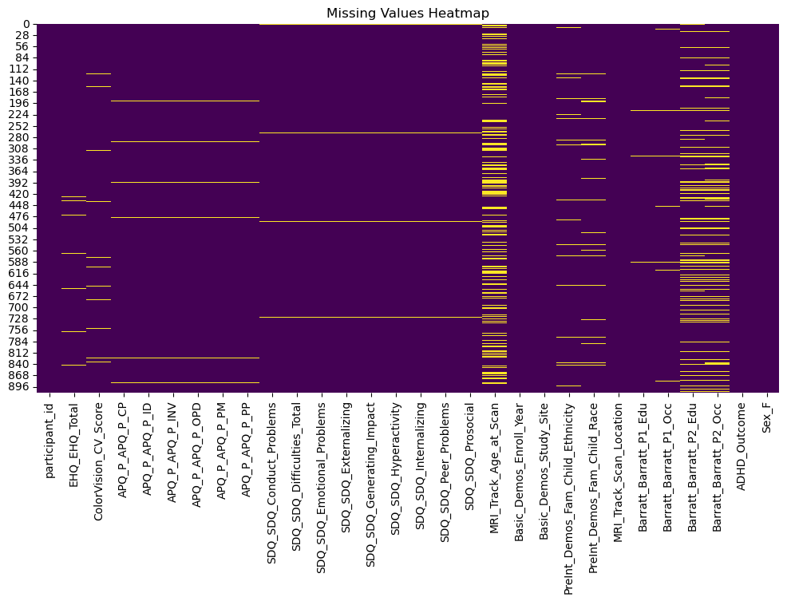

```python
#Visualising Missing Values

plt.figure(figsize=(12, 6))
sns.heatmap(eda_df.isnull(), cbar=False, cmap='viridis')
plt.title("Missing Values Heatmap")
plt.show()
```

```python
missing_summary = (
    eda_df.isnull().sum().to_frame("Missing Values")
    .assign(Total=len(eda_df))
    .assign(Percent=lambda x: round(100 * x["Missing Values"] / x["Total"], 1))
    .sort_values("Missing Values", ascending=False)
)
print(missing_summary.head(10))
```

```
                                  Missing Values  Total  Percent
MRI_Track_Age_at_Scan                        276    910     30.3
Barratt_Barratt_P2_Occ                       157    910     17.3
Barratt_Barratt_P2_Edu                       143    910     15.7
PreInt_Demos_Fam_Child_Race                   39    910      4.3
PreInt_Demos_Fam_Child_Ethnicity              30    910      3.3
ColorVision_CV_Score                          19    910      2.1
Barratt_Barratt_P1_Occ                        17    910      1.9
EHQ_EHQ_Total                                 12    910      1.3
APQ_P_APQ_P_CP                                 9    910      1.0
APQ_P_APQ_P_ID                                 9    910      1.0
```

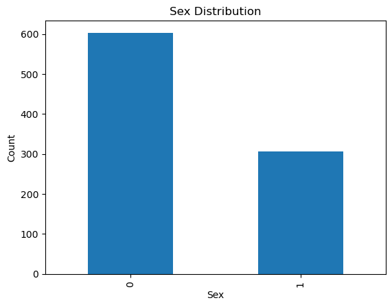

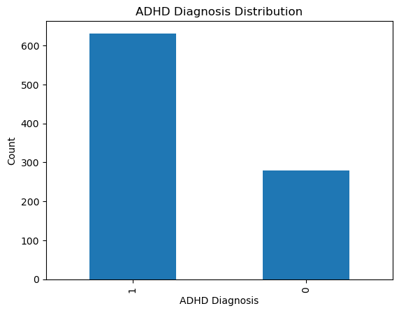

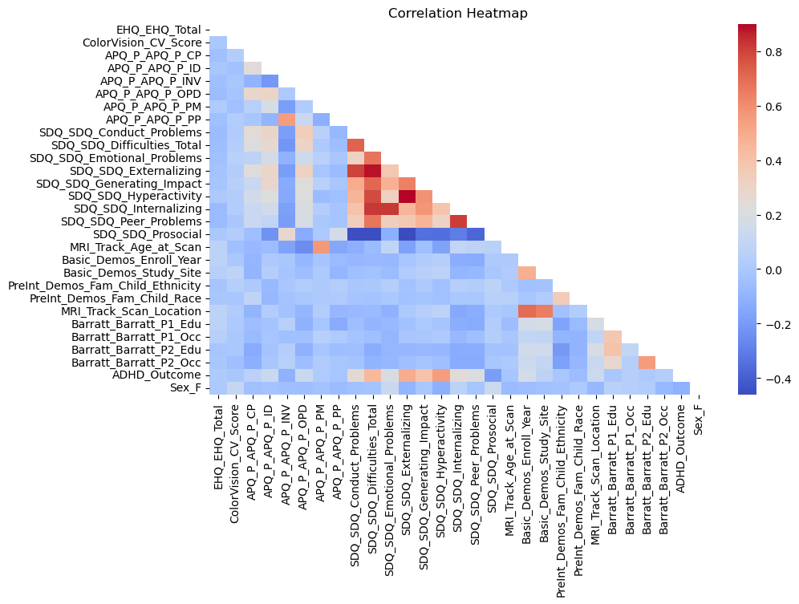

```python
# 1. Sex distribution
eda_df['Sex_F'].value_counts().plot(kind='bar', title='Sex Distribution')
plt.xlabel('Sex'); plt.ylabel('Count')
plt.show()

# 2. ADHD diagnosis distribution
eda_df['ADHD_Outcome'].value_counts().plot(kind='bar', title='ADHD Diagnosis Distribution')
plt.xlabel('ADHD Diagnosis'); plt.ylabel('Count')
plt.show()

# 3. Correlation heatmap (numeric only)
numeric_eda = eda_df.select_dtypes(include=np.number)
correlation = numeric_eda.corr()
mask = np.triu(np.ones_like(correlation, dtype=bool))
plt.figure(figsize=(10, 6))
sns.heatmap(correlation, annot=False, cmap='coolwarm', mask=mask)
plt.title("Correlation Heatmap")
plt.show()
```

```python
race_map = {
    0: "White",
    1: "Black",
    2: "Hispanic",
    3: "Asian",
    4: "Indian",
    5: "Native American",
    6: "American Indian/Alaskan Native",
    7: "Native Hawaiian/Pacific Islander",
    8: "Two or more races",
    9: "Other",
    10: "Unknown",
    11: "Prefer not to say"
}
```

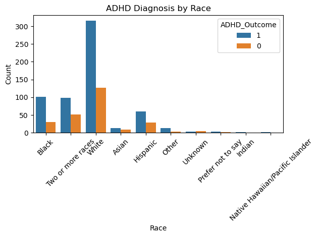

```python
# Safe assignment
eda_df.loc[:, 'Race_Label'] = eda_df['PreInt_Demos_Fam_Child_Race'].map(race_map)

# Convert ADHD outcome to string for seaborn hue
eda_df.loc[:, 'ADHD_Outcome'] = eda_df['ADHD_Outcome'].astype(str)


# Plot
sns.countplot(data=eda_df, x='Race_Label', hue='ADHD_Outcome')
plt.xticks(rotation=45)
plt.title("ADHD Diagnosis by Race")
plt.xlabel("Race")
plt.ylabel("Count")
plt.tight_layout()
plt.show()
```

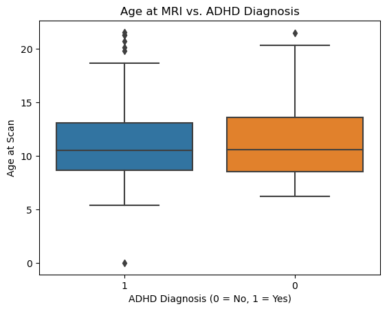

| ADHD_Outcome | count | mean | std | min | 25% | 50% | 75% | max |
| --- | --- | --- | --- | --- | --- | --- | --- | --- |
| 0 | 201.0 | 11.254860 | 3.224434 | 6.191763 | 8.538443 | 10.564225 | 13.594684 | 21.463609 |
| 1 | 433.0 | 11.146295 | 3.238600 | 0.000000 | 8.650011 | 10.541980 | 13.075176 | 21.564453 |

```python
sns.boxplot(data=eda_df, x='ADHD_Outcome', y='MRI_Track_Age_at_Scan')
plt.title("Age at MRI vs. ADHD Diagnosis")
plt.xlabel("ADHD Diagnosis (0 = No, 1 = Yes)")
plt.ylabel("Age at Scan")
plt.show()

eda_df.groupby('ADHD_Outcome')['MRI_Track_Age_at_Scan'].describe()
```

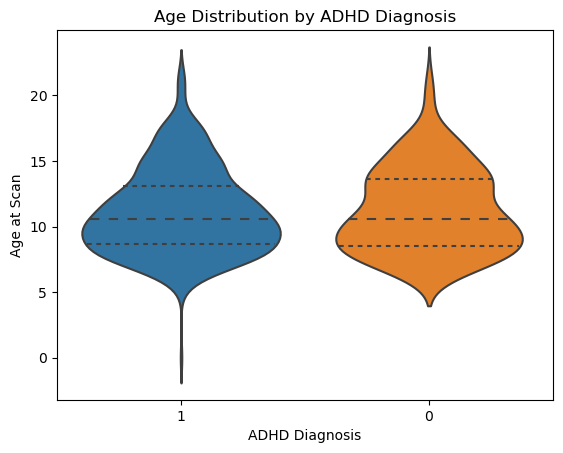

```python
sns.violinplot(data=eda_df, x='ADHD_Outcome', y='MRI_Track_Age_at_Scan', inner='quartile')
plt.title("Age Distribution by ADHD Diagnosis")
plt.xlabel("ADHD Diagnosis")
plt.ylabel("Age at Scan")
plt.show()
```

```
Counts:
ADHD_Outcome    0    1
Sex_Label
Female        115  192
Male          164  439

Row-wise Percentages:
ADHD_Outcome          0          1
Sex_Label
Female        37.459283  62.540717
Male          27.197347  72.802653
```

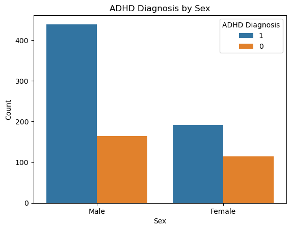

| Sex_Label | ADHD_Outcome | count | mean | std | min | 25% | 50% | 75% | max |
| --- | --- | --- | --- | --- | --- | --- | --- | --- | --- |
| Female | 0 | 84.0 | 11.003423 | 3.323769 | 6.191763 | 8.222164 | 10.336755 | 13.471623 | 18.971937 |
|  | 1 | 127.0 | 10.778044 | 3.279051 | 5.360255 | 8.462868 | 9.975245 | 12.551848 | 21.564453 |
| Male | 0 | 117.0 | 11.435378 | 3.153179 | 6.213324 | 8.861396 | 10.846109 | 13.628108 | 21.463609 |
|  | 1 | 306.0 | 11.299131 | 3.214669 | 0.000000 | 8.802446 | 10.793862 | 13.143423 | 20.694159 |

```python
sex_map = {0: "Male", 1: "Female"}
eda_df.loc[:, 'Sex_Label'] = eda_df['Sex_F'].map(sex_map)


# Counts
print("Counts:")
print(pd.crosstab(eda_df['Sex_Label'], eda_df['ADHD_Outcome']))

# Row-wise percentages
print("\nRow-wise Percentages:")
print(pd.crosstab(eda_df['Sex_Label'], eda_df['ADHD_Outcome'], normalize='index') * 100)

# Convert ADHD outcome to string for plotting (if needed)
eda_df.loc[:, 'ADHD_Outcome'] = eda_df['ADHD_Outcome'].astype(str)


sns.countplot(data=eda_df, x='Sex_Label', hue='ADHD_Outcome')
plt.title("ADHD Diagnosis by Sex")
plt.xlabel("Sex")
plt.ylabel("Count")
plt.legend(title="ADHD Diagnosis")
plt.show()

eda_df.groupby(['Sex_Label', 'ADHD_Outcome'])['MRI_Track_Age_at_Scan'].describe()
```

The connectome data contains 19,900 pre-processed upper-triangle correlations per participant. It was separated out from the EDA, but will be reduced with PCA for modeling.

# Feature Selection

### Shria Narapaneni

```python
#Load the final merged training dataset generated from EDA
# This includes functional connectome features, quantitative/categorical metadata, and ADHD/sex labels
import pandas as pd

#train_df = pd.read_csv('final_train_df.csv')
```

Preview the data types of the first 20 columns to confirm which are numeric Helps identify any object-type columns that need to be excluded before modeling

```python
print(train_df.dtypes.head(20))
print(train_df.columns)
```

```
participant_id        object
0throw_1thcolumn     float64
0throw_2thcolumn     float64
0throw_3thcolumn     float64
0throw_4thcolumn     float64
0throw_5thcolumn     float64
0throw_6thcolumn     float64
0throw_7thcolumn     float64
0throw_8thcolumn     float64
0throw_9thcolumn     float64
0throw_10thcolumn    float64
0throw_11thcolumn    float64
0throw_12thcolumn    float64
0throw_13thcolumn    float64
0throw_14thcolumn    float64
0throw_15thcolumn    float64
0throw_16thcolumn    float64
0throw_17thcolumn    float64
0throw_18thcolumn    float64
0throw_19thcolumn    float64
dtype: object
Index(['participant_id', '0throw_1thcolumn', '0throw_2thcolumn',
       '0throw_3thcolumn', '0throw_4thcolumn', '0throw_5thcolumn',
       '0throw_6thcolumn', '0throw_7thcolumn', '0throw_8thcolumn',
       '0throw_9thcolumn',
       ...
       'Basic_Demos_Study_Site', 'PreInt_Demos_Fam_Child_Ethnicity',
       'PreInt_Demos_Fam_Child_Race', 'MRI_Track_Scan_Location',
       'Barratt_Barratt_P1_Edu', 'Barratt_Barratt_P1_Occ',
       'Barratt_Barratt_P2_Edu', 'Barratt_Barratt_P2_Occ', 'ADHD_Outcome',
       'Sex_F'],
      dtype='object', length=19930)
```

```python
from sklearn.ensemble import RandomForestClassifier
import pandas as pd
import matplotlib.pyplot as plt

# Drop all non-numeric columns (e.g., IDs, unencoded categoricals)
train_df = train_df.select_dtypes(include=['number'])

# missing values quick fix - median imputation
train_df = train_df.fillna(train_df.median(numeric_only=True))
```

Split the dataset into female and male groups using 'Sex_F' Define feature matrices (X) and target labels (y) for both groups

```python
# split by encoded sex (Sex_F: 1=female, 0=male)
X_female = train_df[train_df['Sex_F'] == 1].drop(columns=['ADHD_Outcome', 'Sex_F'])
y_female = train_df[train_df['Sex_F'] == 1]['ADHD_Outcome']

X_male = train_df[train_df['Sex_F'] == 0].drop(columns=['ADHD_Outcome', 'Sex_F'])
y_male = train_df[train_df['Sex_F'] == 0]['ADHD_Outcome']
```

Train separate Random Forest classifiers for predicting ADHD in females and males Using sex-specific data subsets created in the previous step

```python
# train random forests
rf_female = RandomForestClassifier(random_state=42)
rf_female.fit(X_female, y_female)

rf_male = RandomForestClassifier(random_state=42)
rf_male.fit(X_male, y_male)
```

```
RandomForestClassifier(random_state=42)
```

Extract feature importances from each trained Random Forest model Convert them into Pandas Series for easier sorting and plotting

```python
# feature importances
importance_female = pd.Series(rf_female.feature_importances_, index=X_female.columns)
importance_male = pd.Series(rf_male.feature_importances_, index=X_male.columns)
```

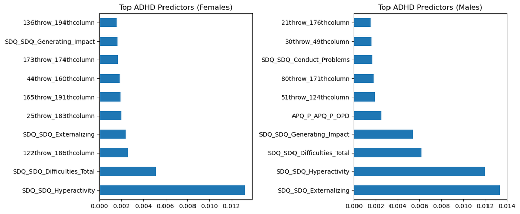

```python
# top features
top_female = importance_female.sort_values(ascending=False).head(10)
top_male = importance_male.sort_values(ascending=False).head(10)

plt.figure(figsize=(12, 5))
plt.subplot(1, 2, 1)
top_female.plot(kind='barh', title='Top ADHD Predictors (Females)')
plt.subplot(1, 2, 2)
top_male.plot(kind='barh', title='Top ADHD Predictors (Males)')
plt.tight_layout()
plt.show()
```

```python
print("Shared top features:", set(top_female.index).intersection(set(top_male.index)))
```

```
Shared top features: {'SDQ_SDQ_Hyperactivity', 'SDQ_SDQ_Difficulties_Total', 'SDQ_SDQ_Generating_Impact', 'SDQ_SDQ_Externalizing'}
```

# Feature Engineering

## 1. Load Dataset and Basic Preprocessing

Step 1–4: Load and Preprocess Data We begin by loading the final merged training dataset and checking its structure. Then, we engineer two new features: age group buckets and a sex–age interaction term. Next, categorical variables like ethnicity, race, and scan location are one-hot encoded. Finally, we prepare our feature matrix X by dropping IDs and target columns, and separately store the targets y_adhd and y_sex for classification.

```python
# Step 1: Load the Dataset
import pandas as pd

# Load the dataset
df = pd.read_csv('/Users/saikiranbommena/Documents/Quarter6/DataScienceCapstone/Dataset/final_merged_training_data.csv')

# Inspect structure
df.info()
df.head()

# Step 2: Feature Engineering

# a. Create Age Buckets
bins = [0, 10, 14, 18, 25]
labels = ['Child', 'Pre-Teen', 'Teen', 'Young Adult']
df['Age_Group'] = pd.cut(df['MRI_Track_Age_at_Scan'], bins=bins, labels=labels)

# b. Create Sex × Age Interaction Term
df['Sex_Age_Interaction'] = df['Sex_F'] * df['MRI_Track_Age_at_Scan']

# Step 3: Handle Categorical Variables

# Identify categorical columns
categorical_cols = ['Age_Group', 'PreInt_Demos_Fam_Child_Ethnicity',
                    'PreInt_Demos_Fam_Child_Race', 'MRI_Track_Scan_Location']

# Convert to nullable integer type for encoding
df[categorical_cols[1:]] = df[categorical_cols[1:]].astype('Int64')

# Apply one-hot encoding
df = pd.get_dummies(df, columns=categorical_cols, drop_first=True)

# Step 4: Prepare Features and Targets

# Drop identifier and target columns from features
X = df.drop(columns=['participant_id', 'ADHD_Outcome', 'Sex_F'])

# Extract targets
y_adhd = df['ADHD_Outcome']
y_sex = df['Sex_F']
```

```
<class 'pandas.core.frame.DataFrame'>
RangeIndex: 1213 entries, 0 to 1212
Columns: 19930 entries, participant_id to Sex_F
dtypes: float64(19925), int64(4), object(1)
memory usage: 184.4+ MB
```

## 2. Dimensionality Reduction, Merge, and Imputation

We loaded PCA-reduced fMRI data, cleaned the participant IDs for consistency, and merged this with the main feature-engineered dataset. This resulted in a combined dataframe with over 20,000 features. After removing non-feature and duplicate columns, we extracted the ADHD and Sex target variables. To handle missing values across all numeric columns, we applied mean imputation using SimpleImputer.

```python
# Step 5: Dimensionality Reduction – Merge PCA Data
import pandas as pd
from sklearn.impute import SimpleImputer

# Load PCA-reduced data
pca_df = pd.read_csv('/Users/saikiranbommena/Documents/Quarter6/DataScienceCapstone/Code/Pca_cabrel/Reduced_Dimension_Data (1).csv')

# Clean participant ID
pca_df['participant_id'] = pca_df['participant_id.3']
cols_to_drop = [col for col in pca_df.columns if 'participant_id' in col and col != 'participant_id']
pca_df = pca_df.drop(columns=cols_to_drop)
pca_df['participant_id'] = pca_df['participant_id'].astype(str).str.strip()
df['participant_id'] = df['participant_id'].astype(str).str.strip()

# Merge PCA and metadata
combined_df = pd.merge(df, pca_df, on='participant_id')
print("Combined shape:", combined_df.shape)

# Step 6: Final Feature Matrix Setup
X_combined = combined_df.drop(columns=['participant_id', 'ADHD_Outcome_x', 'Sex_F_x', 'ADHD_Outcome_y', 'Sex_F_y', 'Unnamed: 0'], errors='ignore')
y_adhd = combined_df['ADHD_Outcome_x']
y_sex = combined_df['Sex_F_x']

# Step 7: Impute Missing Values
imputer = SimpleImputer(strategy='mean')
X_imputed = imputer.fit_transform(X_combined)
```

```
Combined shape: (1213, 20976)
```

## 3. Feature Importance and Evaluation

This block trains a Random Forest model to predict ADHD outcomes, evaluates its accuracy, and plots the top 20 most important features. These features are then exported to a CSV for later analysis.

```
Accuracy: 0.6625514403292181
Classification Report:
               precision    recall  f1-score   support

           0       0.86      0.07      0.13        87
           1       0.66      0.99      0.79       156

    accuracy                           0.66       243
   macro avg       0.76      0.53      0.46       243
weighted avg       0.73      0.66      0.55       243
```

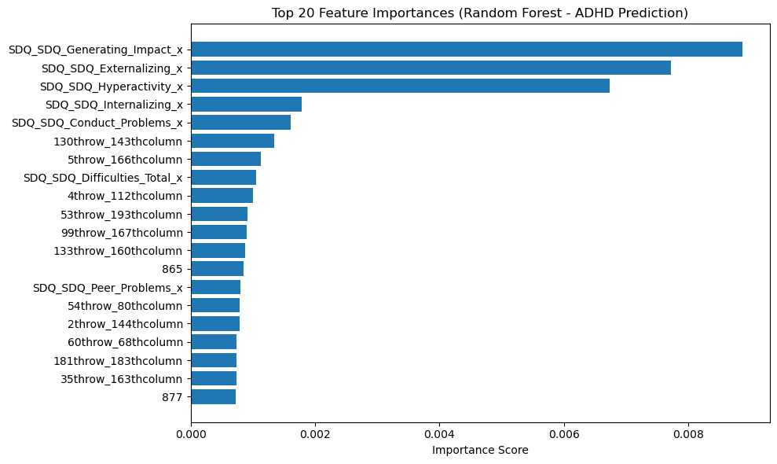

```python
from sklearn.ensemble import RandomForestClassifier
from sklearn.model_selection import train_test_split
from sklearn.metrics import classification_report, accuracy_score
import matplotlib.pyplot as plt
import numpy as np
import pandas as pd
import os

# Split data for ADHD prediction
X_train, X_test, y_train, y_test = train_test_split(X_imputed, y_adhd, test_size=0.2, random_state=42)

# Train model
rf = RandomForestClassifier(n_estimators=100, random_state=42)
rf.fit(X_train, y_train)

# Predict and evaluate
y_pred = rf.predict(X_test)
print("Accuracy:", accuracy_score(y_test, y_pred))
print("Classification Report:\n", classification_report(y_test, y_pred))

# Get feature importances
importances = rf.feature_importances_
indices = np.argsort(importances)[::-1]
top_features = X_combined.columns[indices[:20]]
top_scores = importances[indices[:20]]

# Plot top 20 features
plt.figure(figsize=(10, 6))
plt.title("Top 20 Feature Importances (Random Forest - ADHD Prediction)")
plt.barh(range(20), top_scores[::-1])
plt.yticks(range(20), top_features[::-1])
plt.xlabel("Importance Score")
plt.tight_layout()
plt.show()

# Export to CSV
output_path = '/Users/saikiranbommena/Documents/Quarter6/DataScienceCapstone/Code/Update3_PCA_Engineered'
os.makedirs(output_path, exist_ok=True)

top_rf_df = pd.DataFrame({'Feature': top_features, 'Importance': top_scores})
top_rf_df.to_csv(f"{output_path}/top20_features_random_forest.csv", index=False)
```

## 4. Separate Feature Selection by Sex and for Sex Prediction

This block trains separate Random Forest models to identify top features for ADHD prediction in males and females, and for predicting sex itself. It prints the top 20 important features for each model.

```python
from sklearn.impute import SimpleImputer

df = df.rename(columns=lambda x: x.strip())  # Cleaning any trailing spaces just in case

# Only renaming if both are present, or skip this entirely
if 'ADHD_Outcome' in df.columns and 'Sex_F' in df.columns:
    pass  # already cleaned
else:
    print("Check the column names again")


# Split by sex
df_male = df[df['Sex_F'] == 0]
df_female = df[df['Sex_F'] == 1]

X_male = df_male.drop(columns=['participant_id', 'ADHD_Outcome', 'Sex_F'])
y_male = df_male['ADHD_Outcome']
X_female = df_female.drop(columns=['participant_id', 'ADHD_Outcome', 'Sex_F'])
y_female = df_female['ADHD_Outcome']

imputer = SimpleImputer(strategy='mean')
X_male_imputed = imputer.fit_transform(X_male)
X_female_imputed = imputer.fit_transform(X_female)

rf_male = RandomForestClassifier(n_estimators=100, random_state=42)
rf_female = RandomForestClassifier(n_estimators=100, random_state=42)
rf_male.fit(X_male_imputed, y_male)
rf_female.fit(X_female_imputed, y_female)

top_male_features = X_male.columns[np.argsort(rf_male.feature_importances_)[::-1][:20]]
top_female_features = X_female.columns[np.argsort(rf_female.feature_importances_)[::-1][:20]]

print("Top 20 features for MALES:", top_male_features.tolist())
print("Top 20 features for FEMALES:", top_female_features.tolist())

# Predicting Sex
X_sex = df.drop(columns=['participant_id', 'ADHD_Outcome', 'Sex_F'])
y_sex = df['Sex_F']
X_sex_imputed = imputer.fit_transform(X_sex)

rf_sex = RandomForestClassifier(n_estimators=100, random_state=42)
rf_sex.fit(X_sex_imputed, y_sex)

top_sex_features = X_sex.columns[np.argsort(rf_sex.feature_importances_)[::-1][:20]]
print("Top 20 features for SEX:", top_sex_features.tolist())
```

```
Top 20 features for MALES: ['SDQ_SDQ_Hyperactivity', 'SDQ_SDQ_Externalizing', 'SDQ_SDQ_Difficulties_Total', 'SDQ_SDQ_Generating_Impact', 'SDQ_SDQ_Conduct_Problems', '0throw_38thcolumn', '80throw_197thcolumn', '45throw_196thcolumn', '31throw_114thcolumn', '24throw_177thcolumn', '84throw_143thcolumn',…
Top 20 features for FEMALES: ['SDQ_SDQ_Hyperactivity', 'SDQ_SDQ_Externalizing', 'SDQ_SDQ_Difficulties_Total', '100throw_106thcolumn', '25throw_189thcolumn', '104throw_119thcolumn', '16throw_103thcolumn', '25throw_170thcolumn', '163throw_176thcolumn', '69throw_131thcolumn', '165throw_197thcolumn', '2…
Top 20 features for SEX: ['Sex_Age_Interaction', '57throw_189thcolumn', '180throw_195thcolumn', '141throw_142thcolumn', '49throw_68thcolumn', '131throw_185thcolumn', '83throw_131thcolumn', '30throw_76thcolumn', '167throw_184thcolumn', '98throw_102thcolumn', '81throw_96thcolumn', '27throw_104thcolumn…
```

## 5. Combine and Export Final Feature Set

This block combines the top features from all three models into one final feature set, builds a final dataset for multi-task learning, and exports it to CSV.

```python
# Combine all top features and remove duplicates
final_feature_set = list(set(top_male_features.tolist() + top_female_features.tolist() + top_sex_features.tolist()))
print("Final feature set size:", len(final_feature_set))

# Create final dataset
final_df = df[['participant_id', 'ADHD_Outcome', 'Sex_F'] + final_feature_set]

# Export
final_df.to_csv('/Users/saikiranbommena/Documents/Quarter6/DataScienceCapstone/Code/Update3_PCA_Engineered/final_selected_features_multitask.csv', index=False)
```

```
Final feature set size: 57
```

## 6.Load Dataset and Perform Basic Preprocessing

In this step, we load the final combined dataset that includes PCA-reduced features and engineered metadata. We clean the dataset by removing unused columns, renaming participant IDs if necessary, and creating a clean binary label for sex (0 = Female, 1 = Male). We also create separate subsets for males and females for further feature selection.

```python
import pandas as pd
from sklearn.ensemble import RandomForestClassifier
from sklearn.impute import SimpleImputer

# Load combined dataset
df = pd.read_csv("/Users/saikiranbommena/Documents/Quarter6/DataScienceCapstone/Code/Update3_PCA_Engineered/final_combined_data_update3.csv")

# Drop unnecessary columns and rename participant_id
df.drop(columns=["Unnamed: 0", "Enroll_Year", "Scan_Location"], errors='ignore', inplace=True)
if "participant_id.3" in df.columns:
    df.rename(columns={"participant_id.3": "participant_id"}, inplace=True)

# Create binary 'Sex' column: 0 = female, 1 = male
df["Sex"] = df["Sex_F_x"].apply(lambda x: 0 if x == 1 else 1)

# Split dataset by sex
male_df = df[df["Sex"] == 1]
female_df = df[df["Sex"] == 0]
```

## 7.Feature Selection for ADHD Prediction by Sex

We use a Random Forest classifier to compute feature importances separately for male and female participants. Top 20 features per group are selected based on importance scores. Missing values are imputed using median values before training.

```python
def run_feature_selection_sex_split(data, label_col="ADHD_Outcome_x", top_k=20):
    X = data.drop(columns=["participant_id", "Sex", "ADHD_Outcome_x", "ADHD_Outcome_y"], errors='ignore')
    y = data[label_col]

    imputer = SimpleImputer(strategy="median")
    X_imputed = pd.DataFrame(imputer.fit_transform(X), columns=X.columns)

    rf = RandomForestClassifier(random_state=42)
    rf.fit(X_imputed, y)
    importances = pd.Series(rf.feature_importances_, index=X.columns)
    return importances.sort_values(ascending=False).head(top_k)

# Run feature selection
top_male_adhd = run_feature_selection_sex_split(male_df)
top_male_adhd.to_csv("top_features_adhd_male.csv")

top_female_adhd = run_feature_selection_sex_split(female_df)
top_female_adhd.to_csv("top_features_adhd_female.csv")
```

## 8.Feature Selection for Predicting Sex (All Participants)

We again use a Random Forest model to determine the top 20 features most predictive of biological sex. This is performed on the full dataset.

```python
def run_feature_selection_general(df, target="Sex", top_k=20):
    X = df.drop(columns=["participant_id", "Sex", "ADHD_Outcome_x", "ADHD_Outcome_y"], errors='ignore')
    y = df[target]

    imputer = SimpleImputer(strategy="median")
    X_imputed = pd.DataFrame(imputer.fit_transform(X), columns=X.columns)

    rf = RandomForestClassifier(random_state=42)
    rf.fit(X_imputed, y)
    importances = pd.Series(rf.feature_importances_, index=X.columns)
    return importances.sort_values(ascending=False).head(top_k)

# Get top features for predicting sex
top_sex = run_feature_selection_general(df)
top_sex.to_csv("top_features_sex.csv")
```

## 9.Create Shared Feature Set and Export Final Dataset

We combine the top ADHD-related features (from both male and female models) and top sex-related features into a final shared feature list. This merged feature set is used to build a multi-output classification model for predicting both ADHD and sex.

```python
# Combine ADHD and sex features
adhd_features = pd.concat([top_male_adhd, top_female_adhd]).sort_values(ascending=False).head(20)
sex_features = top_sex
shared_features = list(set(adhd_features.index) | set(sex_features.index))

# Save shared feature list
pd.Series(shared_features).to_csv("shared_top_features.csv", index=False)

# Build and save final dataset
final_df = df[["participant_id", "ADHD_Outcome_x", "Sex"] + shared_features]
final_df.to_csv("final_model_data.csv", index=False)
```

# TEST DATA

This block loads the raw test files, merges them, aligns the PCA columns to training format, handles missing columns, imputes and scales the data, and ensures no target leakage before saving the final clean test set.

```python
import pandas as pd
import numpy as np
from sklearn.impute import SimpleImputer
from sklearn.preprocessing import StandardScaler


# loading test files
test_categorical = pd.read_excel("/Users/saikiranbommena/Documents/Quarter6/DataScienceCapstone/Dataset/widsdatathon2025/TEST/TEST_CATEGORICAL.xlsx")
test_quantitative = pd.read_excel("/Users/saikiranbommena/Documents/Quarter6/DataScienceCapstone/Dataset/widsdatathon2025/TEST/TEST_QUANTITATIVE_METADATA.xlsx")
test_connectome = pd.read_csv("/Users/saikiranbommena/Documents/Quarter6/DataScienceCapstone/Dataset/widsdatathon2025/TEST/TEST_FUNCTIONAL_CONNECTOME_MATRICES.csv")



# Load the training dataset (same one used to train the imputer previously)
df_train = pd.read_csv("/Users/saikiranbommena/Documents/Quarter6/DataScienceCapstone/Code/Update3_PCA_Engineered/Updated_feature_selection/final_model_data.csv")


# Drop non-feature columns
X_train = df_train.drop(columns=["participant_id", "ADHD_Outcome_x", "Sex_F_x"])

# Fit imputer (if not already defined)
from sklearn.impute import SimpleImputer
imputer = SimpleImputer(strategy='mean')
X_train_imputed = imputer.fit_transform(X_train)

# Fit scaler
scaler = StandardScaler()
scaler.fit(X_train_imputed)
```

```
StandardScaler()
```

```python
# Merge categorical and quantitative metadata
test_metadata = pd.merge(test_categorical, test_quantitative, on='participant_id')
participant_ids = test_metadata["participant_id"]

# Drop any target-like columns and participant_id
cols_to_drop = [col for col in test_metadata.columns if 'adhd' in col.lower() or 'sex' in col.lower()]
test_metadata = test_metadata.drop(columns=cols_to_drop + ["participant_id"], errors='ignore')

# Format PCA matrix column names to match training
test_pca = test_connectome.drop(columns=["participant_id"])
test_pca.columns = [f"0throw_{i+1}thcolumn" for i in range(test_pca.shape[1])]

# Combine metadata and PCA
test_combined = pd.concat([test_metadata, test_pca], axis=1)

# Fill missing expected columns and reorder to match training
expected_cols = imputer.feature_names_in_
missing_cols = [col for col in expected_cols if col not in test_combined.columns]
missing_df = pd.DataFrame(0, index=test_combined.index, columns=missing_cols)
test_combined = pd.concat([test_combined, missing_df], axis=1)[expected_cols]

# Transform using training imputer and scaler
X_test_imputed = imputer.transform(test_combined)
X_test_scaled = scaler.transform(X_test_imputed)

# Final test dataset
X_test_final = pd.DataFrame(X_test_scaled, columns=expected_cols)
X_test_final["participant_id"] = participant_ids.values

# Drop any leaked targets
cols_to_drop = [col for col in X_test_final.columns if 'adhd' in col.lower() or 'sex' in col.lower()]
X_test_final.drop(columns=cols_to_drop, inplace=True)

# Save cleaned test data
X_test_final.to_csv("engineered_test_set_clean.csv", index=False)
```

## Feature Importance Visualization

This function trains Random Forests and visualizes the top 20 most important features for ADHD (male/female) and sex prediction, saving each plot to file.

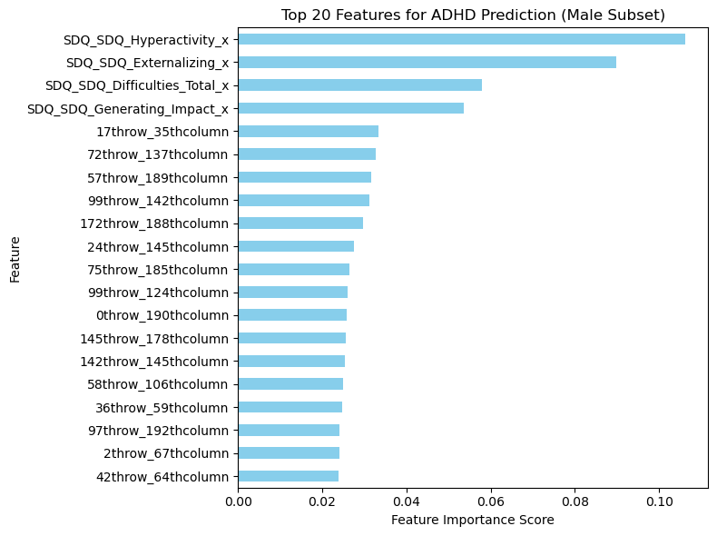

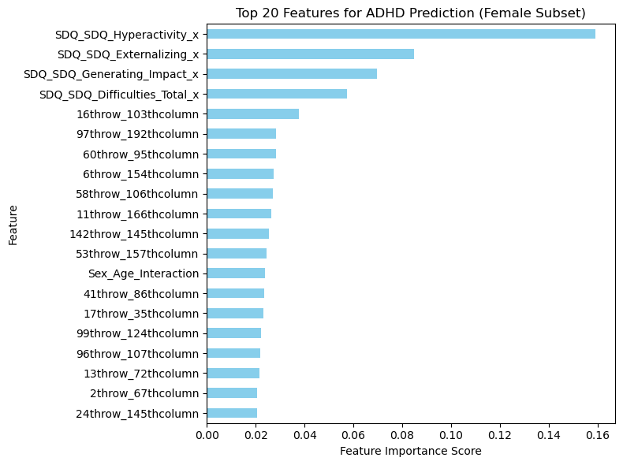

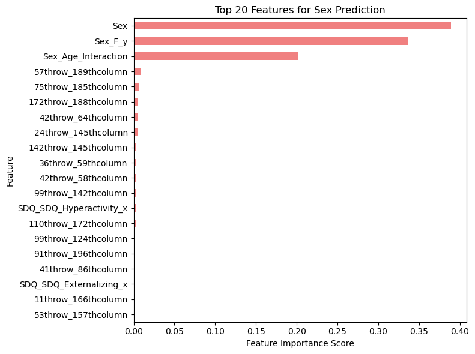

```python
import matplotlib.pyplot as plt
from sklearn.ensemble import RandomForestClassifier

# Define reusable plotting function
def plot_top_features(df, label_col, title, output_file, color):
    X = df.drop(columns=["participant_id", label_col])
    y = df[label_col]

    model = RandomForestClassifier(n_estimators=100, random_state=42)
    model.fit(X, y)

    importances = pd.Series(model.feature_importances_, index=X.columns)
    top_20 = importances.sort_values(ascending=False).head(20)

    plt.figure(figsize=(8, 6))
    top_20.plot(kind="barh", color=color)
    plt.gca().invert_yaxis()
    plt.xlabel("Feature Importance Score")
    plt.ylabel("Feature")
    plt.title(title)
    plt.tight_layout()
    plt.savefig(output_file, dpi=300)
    plt.show()

# Load cleaned modeling dataset
df_model = pd.read_csv("final_model_data.csv").dropna()

# Plot ADHD (male)
plot_top_features(df_model[df_model["Sex_F_x"] == 0], "ADHD_Outcome_x",
                  "Top 20 Features for ADHD Prediction (Male Subset)",
                  "figure_X_ADHD_Male_Feature_Importance.png", "skyblue")

# Plot ADHD (female)
plot_top_features(df_model[df_model["Sex_F_x"] == 1], "ADHD_Outcome_x",
                  "Top 20 Features for ADHD Prediction (Female Subset)",
                  "figure_ADHD_Female_Feature_Importance.png", "skyblue")

# Plot Sex prediction
plot_top_features(df_model, "Sex_F_x", "Top 20 Features for Sex Prediction",
                  "figure_Sex_Feature_Importance.png", "lightcoral")
```

# Performing SVM on All Data, Female Only, Male Only to Predict ADHD

### Multioutput SVM: Johnathen Kent

```python
import sys
import pandas as pd
import csv
import math
import numpy as np
from operator import itemgetter
import time

from sklearn.svm import SVC
from sklearn.ensemble import RandomForestClassifier, RandomForestRegressor
import joblib
from sklearn.feature_selection import RFE, VarianceThreshold, SelectFromModel
from sklearn.feature_selection import SelectKBest, mutual_info_regression, mutual_info_classif, chi2
from sklearn import metrics
from sklearn.model_selection import cross_validate, train_test_split
from sklearn.preprocessing import KBinsDiscretizer, scale
from sklearn.model_selection import train_test_split
from sklearn.preprocessing import StandardScaler
from sklearn.multioutput import MultiOutputClassifier
from sklearn.svm import SVC
```

```python
train_df_all = pd.read_csv('C:\\Users\\fscab_53shzay\\Documents\\DePaulUniversity\\5th Year\\Capstone\\final_merged_training_data.csv')
train_df_all = train_df_all.dropna()
test_df_all = pd.read_csv('C:\\Users\\fscab_53shzay\\Documents\\DePaulUniversity\\5th Year\\Capstone\\final_merged_test_data.csv')

#female only
#train_df_all=train_df_all[train_df_all['Sex_F']==1]
#test df does not have labels.

#male only
#train_df_all=train_df_all[train_df_all['Sex_F']==0]
```

## Preprocessing the Data

```python
# Categorical columns
cat_cols = [
    'PreInt_Demos_Fam_Child_Ethnicity',
    'PreInt_Demos_Fam_Child_Race',
    'Barratt_Barratt_P1_Edu',
    'Barratt_Barratt_P1_Occ',
    'Barratt_Barratt_P2_Edu',
    'Barratt_Barratt_P2_Occ'
]

# Fill missing with "Missing"
for df in [train_df_all, test_df_all]:
    df[cat_cols] = df[cat_cols].fillna("Missing")

# One-hot encode with consistent columns
combined_df = pd.concat([train_df_all, test_df_all], axis=0, ignore_index=True)
combined_encoded = pd.get_dummies(combined_df[cat_cols], prefix=cat_cols, dtype=int)

# Split back
encoded_train = combined_encoded.iloc[:len(train_df_all)].reset_index(drop=True)
encoded_test = combined_encoded.iloc[len(train_df_all):].reset_index(drop=True)

# Drop raw categorical columns
train_df_all = train_df_all.drop(columns=cat_cols)
test_df_all = test_df_all.drop(columns=cat_cols)

# Add encoded
train_df_all = pd.concat([train_df_all.reset_index(drop=True), encoded_train], axis=1)
test_df_all = pd.concat([test_df_all.reset_index(drop=True), encoded_test], axis=1)

# Drop ID and target columns from features
X_train = train_df_all.drop(columns=['participant_id', 'ADHD_Outcome', 'Sex_F'])
y_train = train_df_all[['ADHD_Outcome', 'Sex_F']]
X_test = test_df_all.drop(columns=['participant_id'], errors='ignore')

# After X_train and X_test are created (with all encoded columns)
X_train = X_train.fillna(X_train.median(numeric_only=True))
X_test = X_test.fillna(X_train.median(numeric_only=True))  # use training median to prevent data leakage
print("Missing in X_train:")
print(pd.DataFrame(X_train).isnull().sum().sort_values(ascending=False).head(10))

print("\nMissing in X_test:")
print(pd.DataFrame(X_test).isnull().sum().sort_values(ascending=False).head(10))

# Standardize features
scaler = StandardScaler()
X_train_scaled = scaler.fit_transform(X_train)
X_test_scaled = scaler.transform(X_test)
```

```
Missing in X_train:
0throw_1thcolumn       0
84throw_169thcolumn    0
84throw_176thcolumn    0
84throw_175thcolumn    0
84throw_174thcolumn    0
84throw_173thcolumn    0
84throw_172thcolumn    0
84throw_171thcolumn    0
84throw_170thcolumn    0
84throw_168thcolumn    0
dtype: int64

Missing in X_test:
0throw_1thcolumn       0
84throw_169thcolumn    0
84throw_176thcolumn    0
84throw_175thcolumn    0
84throw_174thcolumn    0
84throw_173thcolumn    0
84throw_172thcolumn    0
84throw_171thcolumn    0
84throw_170thcolumn    0
84throw_168thcolumn    0
dtype: int64
```

```python
#Validation
from sklearn.model_selection import train_test_split

X_train_split, X_val_split, y_train_split, y_val_split = train_test_split(
    X_train_scaled, y_train, test_size=0.2, random_state=42, stratify=y_train['ADHD_Outcome']
)
```

# Multi_Output SVM

```python
#Training Multi_Output SVM
svm = SVC(kernel='rbf', probability=True, class_weight='balanced', random_state=42)
multi_svm = MultiOutputClassifier(svm)

multi_svm.fit(X_train_split, y_train_split)
y_val_pred = multi_svm.predict(X_val_split)

#Results
from sklearn.metrics import classification_report


print("📊 ADHD Diagnosis (Validation):")
print(classification_report(y_val_split['ADHD_Outcome'], y_val_pred[:, 0]))

print("\n📊 Sex Prediction (Validation):")
print(classification_report(y_val_split['Sex_F'], y_val_pred[:, 1]))
```

```
📊 ADHD Diagnosis (Validation):
              precision    recall  f1-score   support

           0       0.27      0.14      0.18        29
           1       0.68      0.83      0.75        64

    accuracy                           0.61        93
   macro avg       0.47      0.48      0.46        93
weighted avg       0.55      0.61      0.57        93


📊 Sex Prediction (Validation):
              precision    recall  f1-score   support

           0       0.61      0.92      0.73        51
           1       0.75      0.29      0.41        42

    accuracy                           0.63        93
   macro avg       0.68      0.60      0.57        93
weighted avg       0.67      0.63      0.59        93
```

### MultiOutput SVM on Top 25 Features

Run when wanting to create Multi & Single Output SVM on Top 25 Features, else skip to Single Output SVM to finsih running all data models

```python
#getting top 25 features
from sklearn.ensemble import RandomForestClassifier

# ADHD model
rf_adhd = RandomForestClassifier(random_state=42)
rf_adhd.fit(X_train, y_train['ADHD_Outcome'])
imp_adhd = rf_adhd.feature_importances_

# Sex model
rf_sex = RandomForestClassifier(random_state=42)
rf_sex.fit(X_train, y_train['Sex_F'])
imp_sex = rf_sex.feature_importances_
```

```python
#bulding features
feature_names = X_train.columns

importance_df = pd.DataFrame({
    'Feature': feature_names,
    'ADHD_Importance': imp_adhd,
    'Sex_Importance': imp_sex
})

importance_df['Avg_Importance'] = (
    importance_df['ADHD_Importance'] + importance_df['Sex_Importance']
) / 2

importance_df_sorted = importance_df.sort_values('Avg_Importance', ascending=False)

#top features
top_features_shared = importance_df_sorted.head(25)['Feature'].tolist()
```

```python
# Subset original unscaled data
X_train_top = X_train[top_features_shared]
X_test_top = X_test[top_features_shared]

# Impute just in case
X_train_top = X_train_top.fillna(X_train_top.median(numeric_only=True))
X_test_top = X_test_top.fillna(X_train_top.median(numeric_only=True))

# Scale
from sklearn.preprocessing import StandardScaler

scaler_top = StandardScaler()
X_train_top_scaled = scaler_top.fit_transform(X_train_top)
X_test_top_scaled = scaler_top.transform(X_test_top)
```

```python
#validation
X_train_top_split, X_val_top_split, y_train_split, y_val_split = train_test_split(
    X_train_top_scaled, y_train, test_size=0.2, random_state=42, stratify=y_train['ADHD_Outcome']
)

#retrain on top features
multi_svm_top = MultiOutputClassifier(SVC(kernel='rbf', class_weight='balanced', probability=True, random_state=42))
multi_svm_top.fit(X_train_top_split, y_train_split)
```

```
MultiOutputClassifier(estimator=SVC(class_weight='balanced', probability=True,
                                    random_state=42))
```

```python
#predict on the test data
y_val_top_pred = multi_svm_top.predict(X_val_top_split)

print("📊 ADHD Diagnosis (Top Features - Validation):")
print(classification_report(y_val_split['ADHD_Outcome'], y_val_top_pred[:, 0]))

print("\n📊 Sex Prediction (Top Features - Validation):")
print(classification_report(y_val_split['Sex_F'], y_val_top_pred[:, 1]))
```

```
📊 ADHD Diagnosis (Top Features - Validation):
              precision    recall  f1-score   support

           0       0.64      0.55      0.59        29
           1       0.81      0.86      0.83        64

    accuracy                           0.76        93
   macro avg       0.72      0.71      0.71        93
weighted avg       0.76      0.76      0.76        93


📊 Sex Prediction (Top Features - Validation):
              precision    recall  f1-score   support

           0       0.70      0.69      0.69        51
           1       0.63      0.64      0.64        42

    accuracy                           0.67        93
   macro avg       0.66      0.66      0.66        93
weighted avg       0.67      0.67      0.67        93
```

```python
print("Top Shared Features",top_features_shared)
```

```
Top Shared Features ['SDQ_SDQ_Hyperactivity', 'SDQ_SDQ_Difficulties_Total', 'SDQ_SDQ_Generating_Impact', 'SDQ_SDQ_Externalizing', 'SDQ_SDQ_Internalizing', '164throw_176thcolumn', '85throw_190thcolumn', '43throw_147thcolumn', '37throw_130thcolumn', '96throw_169thcolumn', '46throw_107thcolumn', '43thr…
```

# Regular SVM

### SVM: Fernanda Cabral

```python
#Training SVM
from sklearn.metrics import classification_report
scorers = {'Accuracy': 'accuracy', 'roc_auc': 'roc_auc'}
start_ts=time.time()

#cross validated
svm = SVC(kernel='rbf', probability=True, class_weight='balanced', random_state=42)
scores=cross_validate(svm, X_train_split, y_train_split['ADHD_Outcome'], scoring=scorers, cv=5)

#single validation
svm2 = svm.fit(X_train_split, y_train_split['ADHD_Outcome'])
y_val_pred = svm2.predict(X_val_split)
```

```python
print("ADHD Diagnosis (Validation):")
print(classification_report(y_val_split['ADHD_Outcome'], y_val_pred))

scores_Acc = scores['test_Accuracy']
print("SVM Acc: %0.2f (+/- %0.2f)" % (scores_Acc.mean(), scores_Acc.std() * 2))
scores_AUC= scores['test_roc_auc']
print("SVM AUC: %0.2f (+/- %0.2f)" % (scores_AUC.mean(), scores_AUC.std() * 2))
print("CV Runtime:", time.time()-start_ts)
```

```
ADHD Diagnosis (Validation):
              precision    recall  f1-score   support

           0       0.27      0.14      0.18        29
           1       0.68      0.83      0.75        64

    accuracy                           0.61        93
   macro avg       0.47      0.48      0.46        93
weighted avg       0.55      0.61      0.57        93

SVM Acc: 0.66 (+/- 0.08)
SVM AUC: 0.56 (+/- 0.15)
CV Runtime: 102.45804166793823
```

Female Only Reuslts:  
SVM Acc: 0.59 (+/- 0.07) SVM AUC: 0.53 (+/- 0.07) CV Runtime: 13.061468362808228

Male Only Results:  
SVM Acc: 0.73 (+/- 0.04) SVM AUC: 0.57 (+/- 0.13) CV Runtime: 62.10119414329529

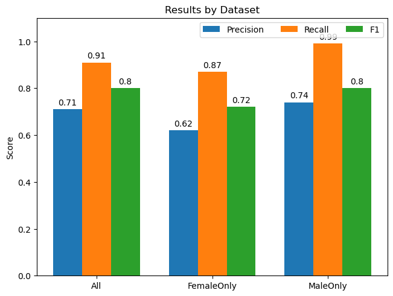

```python
import matplotlib.pyplot as plt
#Visualizing Results
#All Data, Female Only, Male Only
#ADHD_Results = {}
ADHD_Results = {'All Data': [0.9, 0.86, 0.88], 'Female Only':[0.91, 0.81, 0.86], 'Male Only': [0.93, 0.78, 0.85]}

dataset = ("All", "FemaleOnly", "MaleOnly")
results = {
    'Precision': (0.71, 0.62, 0.74), 'Recall': (0.91,0.87,0.99), 'F1': (0.80,0.72,0.80),
}

x = np.arange(len(dataset))  # the label locations
width = 0.25  # the width of the bars
multiplier = 0

fig, ax = plt.subplots(layout='constrained')

for attribute, measurement in results.items():
    offset = width * multiplier
    rects = ax.bar(x + offset, measurement, width, label=attribute)
    ax.bar_label(rects, padding=3)
    multiplier += 1

# Add some text for labels, title and custom x-axis tick labels, etc.
ax.set_ylabel('Score')
ax.set_title('Results by Dataset')
ax.set_xticks(x + width, dataset)
ax.legend(loc='best', ncols=3)
ax.set_ylim(0, 1.1)

plt.show()
```

# Using Engineered Feature Data for Single SVM

```python
train_df = pd.read_csv('C:\\Users\\fscab_53shzay\\Documents\\DePaulUniversity\\5th Year\\Capstone\\final_model_data.csv')
train_df = train_df.dropna()

#female only
#train_df=train_df[train_df['Sex_F_x']==1]

#male only
#train_df=train_df[train_df['Sex_F_x']==0]

train_df = train_df.drop(columns=['participant_id', 'Sex', 'Sex_F_y'])
train_df.head()
```

|  | ADHD_Outcome_x | 0throw_190thcolumn | Sex_F_x | 41throw_86thcolumn | 72throw_137thcolumn | 11throw_166thcolumn | 36throw_59thcolumn | 75throw_185thcolumn | 16throw_103thcolumn | 2throw_67thcolumn | ... | SDQ_SDQ_Hyperactivity_x | 172throw_188thcolumn | 142throw_145thcolumn | 60throw_95thcolumn | SDQ_SDQ_Difficulties_Total_x | 97throw_192thcolumn | 96throw_107thcolumn | 57throw_189thcolumn | 6throw_154thcolumn | SDQ_SDQ_Internalizing_x |
| --- | --- | --- | --- | --- | --- | --- | --- | --- | --- | --- | --- | --- | --- | --- | --- | --- | --- | --- | --- | --- | --- |
| 0 | 1 | -0.168477 | 0 | -0.151908 | 0.028898 | -0.071579 | 0.272145 | 0.236684 | 0.272842 | -0.224341 | ... | 4.0 | -0.068615 | 0.491315 | 0.190431 | 8.0 | 0.143178 | 0.387484 | -0.331772 | 0.051859 | 4.0 |
| 2 | 1 | -0.036417 | 1 | -0.176035 | -0.025954 | 0.019575 | 0.080984 | 0.507463 | -0.218475 | -0.383027 | ... | 9.0 | 0.362422 | 0.509171 | -0.014093 | 26.0 | -0.159663 | 0.419522 | 0.292805 | 0.024029 | 9.0 |
| 6 | 0 | -0.132751 | 0 | -0.287752 | -0.314113 | 0.085731 | -0.050099 | 0.434357 | 0.139996 | 0.134216 | ... | 4.0 | -0.019671 | 0.211172 | 0.540557 | 17.0 | -0.235338 | 0.463231 | -0.408147 | 0.043557 | 9.0 |
| 7 | 1 | -0.323455 | 0 | -0.094683 | -0.071562 | 0.187881 | 0.385584 | -0.129865 | 0.335379 | 0.233426 | ... | 9.0 | 0.064566 | 0.186834 | -0.036083 | 12.0 | -0.055985 | 0.514984 | -0.012963 | -0.145187 | 3.0 |
| 10 | 0 | -0.087551 | 1 | 0.036811 | -0.119375 | -0.370062 | 0.375362 | 0.478430 | 0.147430 | -0.433209 | ... | 8.0 | 0.371813 | 0.435591 | 0.272316 | 22.0 | 0.137798 | 0.560753 | 0.236110 | 0.131650 | 10.0 |

5 rows × 35 columns

```python
X_data = train_df.iloc[:,1:]
y_data = train_df['ADHD_Outcome_x']
```

```python
#Validation
from sklearn.model_selection import train_test_split
X_train_split, X_val_split, y_train_split, y_val_split = train_test_split(
    X_data, y_data, test_size=0.2, random_state=42
)
# Standardize features
scaler = StandardScaler()
X_train_scaled = scaler.fit_transform(X_train_split)
X_val_scaled = scaler.transform(X_val_split)
```

# SVM

```python
#Training SVM
from sklearn.metrics import classification_report
scorers = {'Accuracy': 'accuracy', 'roc_auc': 'roc_auc'}
start_ts=time.time()

#cross validated
svm = SVC(kernel='rbf', probability=True, class_weight='balanced', random_state=42)
scores=cross_validate(svm, X_train_split, y_train_split, scoring=scorers, cv=5)

#single validation
svm2 = svm.fit(X_train_split, y_train_split)
y_val_pred = svm2.predict(X_val_split)
```

```python
print("ADHD (Validation):")
#print(classification_report(y_train_split['ADHD_Outcome'], y_val_pred[:,0]))

scores_Acc = scores['test_Accuracy']
print("SVM Acc: %0.2f (+/- %0.2f)" % (scores_Acc.mean(), scores_Acc.std() * 2))
scores_AUC= scores['test_roc_auc']
print("SVM AUC: %0.2f (+/- %0.2f)" % (scores_AUC.mean(), scores_AUC.std() * 2))
print("CV Runtime:", time.time()-start_ts)

print(classification_report(y_val_split, y_val_pred))
```

```
ADHD (Validation):
SVM Acc: 0.76 (+/- 0.07)
SVM AUC: 0.84 (+/- 0.05)
CV Runtime: 7.699703931808472
              precision    recall  f1-score   support

           0       0.61      0.73      0.67        59
           1       0.84      0.75      0.79       110

    accuracy                           0.75       169
   macro avg       0.73      0.74      0.73       169
weighted avg       0.76      0.75      0.75       169
```

[output not shown]

Female Only:  
ADHD Diagnosis (Validation):  
SVM Acc: 0.78 (+/- 0.18)  
SVM AUC: 0.88 (+/- 0.16)  
CV Runtime: 1.898186206817627

```
          precision    recall  f1-score   support

       0       0.72      0.86      0.78        21
       1       0.91      0.81      0.86        37

accuracy                           0.83        58
```

macro avg 0.81 0.83 0.82 58 weighted avg 0.84 0.83 0.83 58

Male Only:  
ADHD Diagnosis (Validation):  
SVM Acc: 0.80 (+/- 0.06)  
SVM AUC: 0.92 (+/- 0.06)  
CV Runtime: 2.348987102508545

```
          precision    recall  f1-score   support

       0       0.58      0.83      0.68        30
       1       0.93      0.78      0.85        82

accuracy                           0.79       112
```

macro avg 0.75 0.81 0.77 112 weighted avg 0.83 0.79 0.80 112

### Predicting Sex:

Sex F (Validation):  
SVM Acc: 1.00 (+/- 0.01)  
SVM AUC: 1.00 (+/- 0.00)  
CV Runtime: 3.037538528442383\

```
          precision    recall  f1-score   support

       0       1.00      1.00      1.00       113
       1       1.00      1.00      1.00        56

accuracy                           1.00       169
```

macro avg 1.00 1.00 1.00 169 weighted avg 1.00 1.00 1.00 169

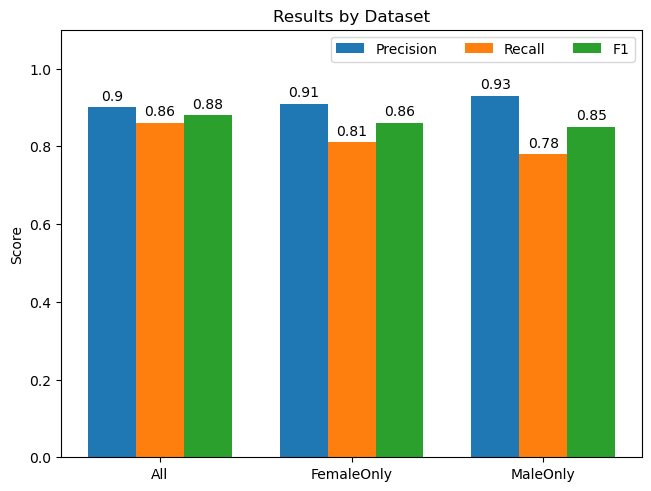

```python
import matplotlib.pyplot as plt
#Visualizing Results
#All Data, Female Only, Male Only
#ADHD_Results = {}
ADHD_Results = {'All Data': [0.9, 0.86, 0.88], 'Female Only':[0.91, 0.81, 0.86], 'Male Only': [0.93, 0.78, 0.85]}

dataset = ("All", "FemaleOnly", "MaleOnly")
results = {
    'Precision': (0.9, 0.91, 0.93), 'Recall': (0.86, 0.81, 0.78), 'F1': (0.88, 0.86, 0.85),
}

x = np.arange(len(dataset))  # the label locations
width = 0.25  # the width of the bars
multiplier = 0

fig, ax = plt.subplots(layout='constrained')

for attribute, measurement in results.items():
    offset = width * multiplier
    rects = ax.bar(x + offset, measurement, width, label=attribute)
    ax.bar_label(rects, padding=3)
    multiplier += 1

# Add some text for labels, title and custom x-axis tick labels, etc.
ax.set_ylabel('Score')
ax.set_title('Results by Dataset')
ax.set_xticks(x + width, dataset)
ax.legend(loc='best', ncols=3)
ax.set_ylim(0, 1.1)

plt.show()
```

# MultiOutput SVM on Feature Engineered

```python
train_df = pd.read_csv('C:\\Users\\fscab_53shzay\\Documents\\DePaulUniversity\\5th Year\\Capstone\\final_model_data.csv')
train_df = train_df.dropna()

#female only
#train_df=train_df[train_df['Sex_F_x']==1]

#male only
#train_df=train_df[train_df['Sex_F_x']==0]

train_df = train_df.drop(columns=['participant_id', 'Sex', 'Sex_F_y'])
train_df.head()
```

|  | ADHD_Outcome_x | 0throw_190thcolumn | Sex_F_x | 41throw_86thcolumn | 72throw_137thcolumn | 11throw_166thcolumn | 36throw_59thcolumn | 75throw_185thcolumn | 16throw_103thcolumn | 2throw_67thcolumn | ... | SDQ_SDQ_Hyperactivity_x | 172throw_188thcolumn | 142throw_145thcolumn | 60throw_95thcolumn | SDQ_SDQ_Difficulties_Total_x | 97throw_192thcolumn | 96throw_107thcolumn | 57throw_189thcolumn | 6throw_154thcolumn | SDQ_SDQ_Internalizing_x |
| --- | --- | --- | --- | --- | --- | --- | --- | --- | --- | --- | --- | --- | --- | --- | --- | --- | --- | --- | --- | --- | --- |
| 0 | 1 | -0.168477 | 0 | -0.151908 | 0.028898 | -0.071579 | 0.272145 | 0.236684 | 0.272842 | -0.224341 | ... | 4.0 | -0.068615 | 0.491315 | 0.190431 | 8.0 | 0.143178 | 0.387484 | -0.331772 | 0.051859 | 4.0 |
| 2 | 1 | -0.036417 | 1 | -0.176035 | -0.025954 | 0.019575 | 0.080984 | 0.507463 | -0.218475 | -0.383027 | ... | 9.0 | 0.362422 | 0.509171 | -0.014093 | 26.0 | -0.159663 | 0.419522 | 0.292805 | 0.024029 | 9.0 |
| 6 | 0 | -0.132751 | 0 | -0.287752 | -0.314113 | 0.085731 | -0.050099 | 0.434357 | 0.139996 | 0.134216 | ... | 4.0 | -0.019671 | 0.211172 | 0.540557 | 17.0 | -0.235338 | 0.463231 | -0.408147 | 0.043557 | 9.0 |
| 7 | 1 | -0.323455 | 0 | -0.094683 | -0.071562 | 0.187881 | 0.385584 | -0.129865 | 0.335379 | 0.233426 | ... | 9.0 | 0.064566 | 0.186834 | -0.036083 | 12.0 | -0.055985 | 0.514984 | -0.012963 | -0.145187 | 3.0 |
| 10 | 0 | -0.087551 | 1 | 0.036811 | -0.119375 | -0.370062 | 0.375362 | 0.478430 | 0.147430 | -0.433209 | ... | 8.0 | 0.371813 | 0.435591 | 0.272316 | 22.0 | 0.137798 | 0.560753 | 0.236110 | 0.131650 | 10.0 |

5 rows × 35 columns

```python
X_data = train_df.iloc[:,1:]
X_data=X_data.drop(columns=['Sex_F_x'])
y_data = train_df[['ADHD_Outcome_x', 'Sex_F_x']]
```

[output not shown]

845 rows × 33 columns

```python
#Validation
from sklearn.model_selection import train_test_split
X_train_split, X_val_split, y_train_split, y_val_split = train_test_split(
    X_data, y_data, test_size=0.2, random_state=42
)
# Standardize features
scaler = StandardScaler()
X_train_scaled = scaler.fit_transform(X_train_split)
X_val_scaled = scaler.transform(X_val_split)
```

```python
#MULTI SVM
#retrain on top features
multi_svm = MultiOutputClassifier(SVC(kernel='rbf', class_weight='balanced', probability=True, random_state=42))
multi_svm.fit(X_train_split, y_train_split)
#predict on the test data
y_val_pred = multi_svm.predict(X_val_split)

print("📊 ADHD Diagnosis (Top Features - Validation):")
print(classification_report(y_val_split['ADHD_Outcome_x'], y_val_pred[:, 0]))

print("\n📊 Sex Prediction (Top Features - Validation):")
print(classification_report(y_val_split['Sex_F_x'], y_val_pred[:, 1]))
```

```
📊 ADHD Diagnosis (Top Features - Validation):
              precision    recall  f1-score   support

           0       0.61      0.73      0.67        59
           1       0.84      0.75      0.79       110

    accuracy                           0.75       169
   macro avg       0.73      0.74      0.73       169
weighted avg       0.76      0.75      0.75       169


📊 Sex Prediction (Top Features - Validation):
              precision    recall  f1-score   support

           0       1.00      1.00      1.00       113
           1       1.00      1.00      1.00        56

    accuracy                           1.00       169
   macro avg       1.00      1.00      1.00       169
weighted avg       1.00      1.00      1.00       169
```